# データ解析論I第6講

## Table of content

## 前回の復習

## データの順序付け

- データの順序付け：データを分析しやすいように並び替えること．
  - 分析をしやすいように並べ変える必要があることがある．
  - Rでは自動的にアルファベット順に並べてくれる．
- 最初にデータを読み込んでおきましょう．

## 地域の並べ替え

```r
head(factor(exdataset$ARE))
```

```
## [1] Hokkaido Chubu    Chubu    Kanto    Kyushu   Chubu
## Levels: Chubu Chugoku Hokkaido Kanto Kinki Kyushu Shikoku Tohoku
```

## 地域の並べ替え

```r
## Reordering exdataset$ARE
exdataset$ARE <- factor(exdataset$ARE, levels=c("Kanto", "Hokkaido", "Tohoku", "Chubu", "Kinki", "Chugoku", "Shikoku", "Kyushu"))
head(factor(exdataset$ARE))
```

```
## [1] Hokkaido Chubu    Chubu    Kanto    Kyushu   Chubu
## Levels: Kanto Hokkaido Tohoku Chubu Kinki Chugoku Shikoku Kyushu
```

- Levelsを確認すると，関東を始めとして，北海道，東北，中部，近畿，中国，四国，九州の順番に並べ替えられる．
- 『関東』を最初にする理由は今後紹介するが，「比較の基準」とするモノを設定する必要がある．

## アドインの追加

```
install.packages("addinslist")
```

- インストールした後に，“Addins”をクリックする．
- “Browse RStudion Addins”をクリックする
- “order”で検索
- “questionr”をインストール
- (Addinsをクリックして表示されなければ)RStudioをとじて，再度立ち上げる．
- “Addins”→“Levels Ordering”を選択
- “exdataset”→“ARE”を選択
- “Ordering”タブを選んで，並べ替える．

## 結婚と子どもの有無についても並べ替えよう．

```r
head(factor(exdataset$MAR))
```

```
## [1] Married    NotMarried Married    NotMarried Married    NotMarried
## Levels: Married NotMarried
```

- NotMarried(未婚)を最初として，次にMarried(既婚)として並べ替えよう．

```r
head(factor(exdataset$CHI))
```

```
## [1] Child   NoChild Child   NoChild NoChild Child
## Levels: Child NoChild
```

- NoChild(子どもなし)を最初として，次にChild(子どもあり)として並べ替えよう．
- 並べ替えを手抜きするために“Addin”を使えば，クリックだけでいろいろできる．

## 回答

```r
## Reordering exdataset$MAR
exdataset$MAR <- factor(exdataset$MAR, levels=c("NotMarried", "Married"))
```

```r
## Reordering exdataset$CHI
exdataset$CHI <- factor(exdataset$CHI, levels=c("NoChild", "Child"))
```

## データのフィルタリング

- データのフィルタリングとは：データを一定の基準で分けること
  - ex.データを男性によるデータと女性によるデータに分けて分析を行う

## 男性だけのデータの平均値

- `exdataset$F_SEX`の`male(男性)`のみを取り出して，`exdataset_male`というデータセットを作って`SUB_HAP(主観的幸福度)`の平均値を算出してみましょう．
- 最初にデータ全体の主観的幸福度の平均値を確認しておきましょう．

```r
mean(exdataset$SUB_HAP)
```

```
## [1] 6.002077
```

## 男性だけのデータの平均値

```r
# install.packages('dplyr', dependencies = T)：1回目だけ
library(dplyr)
 # dplyrという関数を用いる．
```

```r
exdataset_male <- exdataset %>%
  filter(F_SEX == "male")

 # `exdataset`について，`F_SEX`が`male`であるデータだけを取り出す．
 # `=`ではなく，`==`であることに注意しよう．

head(factor(exdataset_male$F_SEX))
```

```
## [1] male male male male male male
## Levels: male
```

```r
mean(exdataset_male$SUB_HAP)
```

```
## [1] 5.491358
```

## 演習問題：女性のデータだけを取り出す．

- `exdataset$F_SEX`の`female(女性)`のみを取り出して，`exdataset_female`というデータセットを作って`SUB_HAP(主観的幸福度)`の平均値を算出してみましょう．
  - 各自でやってみましょう．

## 回答

```r
exdataset_female <- exdataset %>% filter(F_SEX == "female")
 # `exdataset`について，`F_SEX`が`female`であるデータだけを取り出す．
 # `=`ではなく，`==`であることに注意しよう．

head(factor(exdataset_female$F_SEX))
```

```
## [1] female female female female female female
## Levels: female
```

```r
mean(exdataset_female$SUB_HAP)
```

```
## [1] 6.376812
```

## jamoviでの扱い方

## 動画を参照のこと

- データの順序付け
  - 地域の並べ替え
  - 結婚・子どもの有無の並べ替え（演習）
- データのフィルタリング
  - 男性だけのデータの平均値
  - 女性だけのデータの平均値（演習）

## 今日の本題

## 実証分析の手続き

## 実証分析とは：

- 実証分析：**客観的に**たくさんのケースにまたがって多量のデータを収集した上で，**統計的**な手法によってそれを分析しようとする方法（森田, 2014）．
  - ただし，個別具体的な事例に踏み込んでの議論には合わないが，**一般性・客観性のある議論には適している**．
  - 個別具体的な事例に踏み込んだ議論は分析者の主観的観点が含まれてしまうために，客観性に劣ってしまう．
  - いわゆる「質的研究」が抱える課題

## データの分類

- 「データの分類」を改めて確認しましょう．

| 量的／質的 | データの名称 | 測定尺度 | 直接できる演算 | 主な代表値 |
| --- | --- | --- | --- | --- |
| 量的データ | 比率データ | 比率尺度 | ＋－×÷ | 各種平均 |
| 量的データ | 間隔データ | 間隔尺度 | ＋－ | 算術平均 |
| 質的データ | 順位データ | 順位尺度 | ＞＝ | 中央値 |
| 質的データ | カテゴリデータ | 名義尺度 | 度数カウント | 最頻値 |

（参考：入門統計学-検定から多変量解析・実験計画法まで-(栗原伸一)）

## 仮説とは

これから統計的な手法を学ぶ上で，大事なことは「仮説検証」という考え方です．統計学は「対立仮説」と「帰無仮説」の2つの仮説を元に考えていきます．

## 帰無仮説と対立仮説

- 対立仮説：一番主張したいこと，\(H_1\)
  - ゴトウは若い．
  - ゴトウはイケメンである．
  - カレーは飲み物である．
  - 授業は楽しい．
- 帰無仮説：主張したいことではないこと，\(H_0\)
  - ゴトウは若いとはいえない．
  - ゴトウはイケメンであるとはいえない．
  - カレーは飲み物であるとはいえない．
  - 授業は楽しいとはいえない．
- 対立仮説：一番主張したいことです．
  - 統計学ではこの「対立仮説」を「採択」するためにあーでもない，こーでもないとひたすら戦います．一方，この対立仮説が採択されなかった場合には，「帰無仮説」が採択されることになります．
- 「帰無仮説」の各項目を見てみると，いずれも煮え切らない態度でイライラするかもしれません．しかし，統計学では実は対立仮説が選ばれなかった場合には，この煮え切らないイライラする結論しか出せないのです．

> 昨今では，この煮え切らないイライラする姿勢は良くない！ということで「ベイズ統計学」という手法であったり，「効果量」という概念を用いて分析・検討を行うことがあります．この点についてはこの授業の中では触れられないので，ご了承ください． でも，ちょっとやってみたい！って方がいればやってみましょう．

まずは「対立仮説」と「帰無仮説」という考え方を理解して下さい．その上で，統計分析を行うときにはその仮説にあわせて手法を考えることになります．

途中で対立仮説や帰無仮説を「選ぶ」or「採択する」という表現が出てきました．統計学では，この選んだり採択する基準として「p値」というものを使います．正確には，「平均や標準偏差などを計算する」→「t値やz値を算出する」→「p値を算出する」という手順を踏むことになります．

この授業では，基本的な考え方を理解してもらった上で，実際に関連する数値を見て分析・考えていくという流れを追いますが，一部には時間の都合上，説明が端的になってしまう部分もあります．その際は，各自で統計学に関する教科書を覗いていただければ幸いです．

## 分析の方法による仮説の作り方

※ここでは基本的な分類のみを説明しています．

### **関係**を明らかにする分析手法

- 回帰分析：Aという変数とBという変数の間に相関があるか否か
  - 応答変数：量的変数
  - 説明変数：量的変数
- **\(\chi\)二乗検定**：A群とB群の間が独立しているか否か
  - 応答変数：質的変数
  - 説明変数：質的変数

### **差異**を明らかにする分析手法

- t検定：A群とB群の間に差があるか否か
  - 応答変数：量的変数
  - 説明変数：質的変数(2値データ)
- 分散分析：A群とB群とC群と．．．の間に差があるか否か
  - 応答変数：量的変数
  - 説明変数：質的変数(3つ以上のデータ)

### **差異**を一定にしたまま**関係**を明らかにする分析手法or**関係**を一定にしたまま**差異**を明らかにする分析手法

- 重回帰分析
  - 応答変数：量的変数
  - 説明変数：質的変数複数or量的変数複数or量的変数＆質的変数etc…

## クロス集計

## クロス集計：

- **クロス集計表**：複数の質問項目を組み合わせて集計する手法
  - ex. 朝食を食べているか否か×深夜アルバイトしているか否かなど．
  - 企業の中でも基本的な統計手法としてよく用いられている．
  - 2つの質的変数間の関連性である「連関」を示す．

## 組み合わせの数をカウントする．

- 使用するパッケージ

```r
library(dplyr)
  # インストールしていなければ，最初はinstall.packages("dplyr")をしておきましょう．
library(tidyr)
  # インストールしていなければ，最初はinstall.packages("tidyr")をしておきましょう．
```

## 地域ごとに子どもがいる人の数を数える．

- 2つの手法
  - dplyrのgroup_by関数を使う方法
  - table 関数を使う方法
  - 現在では前者がメインの手法だが，念のために後者の方法についても紹介する．
  - 今の御時世の最先端の関数を使っている

## dplyrのgroup_by関数を使う方法

```r
tablea<-exdataset %>%
  group_by(ARE, CHI) %>% # 地域ごとにまとめる関数
  tally() %>% # 地域ごとに数える関数
  spread(ARE, n) # 数えた結果を地域ごとにまとめる関数
tablea
```

```
## # A tibble: 2 x 9
##   CHI     Kanto Hokkaido Tohoku Chubu Kinki Chugoku Shikoku Kyushu
##   <chr>   <int>    <int>  <int> <int> <int>   <int>   <int>  <int>
## 1 Child     184       21     29    80    86      34       8     53
## 2 NoChild   192       14     35    68    79      31      10     39
```

## dplyrのgroup_by関数を使う方法

- ちなみに，panderという関数を使うとキレイにテーブルとして出力できる．

```r
# install.packages(pander) # 初回のみインストールが必要
library(pander)
pander(tablea)
```

| CHI | Kanto | Hokkaido | Tohoku | Chubu | Kinki | Chugoku | Shikoku | Kyushu |
| --- | --- | --- | --- | --- | --- | --- | --- | --- |
| Child | 184 | 21 | 29 | 80 | 86 | 34 | 8 | 53 |
| NoChild | 192 | 14 | 35 | 68 | 79 | 31 | 10 | 39 |

## dplyrのcount関数を使う方法

```r
tableb<-exdataset %>%
  count(ARE, CHI) %>%
  spread(ARE, n)
tableb
```

```
## # A tibble: 2 x 9
##   CHI     Kanto Hokkaido Tohoku Chubu Kinki Chugoku Shikoku Kyushu
##   <chr>   <int>    <int>  <int> <int> <int>   <int>   <int>  <int>
## 1 Child     184       21     29    80    86      34       8     53
## 2 NoChild   192       14     35    68    79      31      10     39
```

## dplyrのcount関数を使う方法

- ちなみに，panderという関数を使うとキレイにテーブルとして出力できる．

```r
pander(tableb)
```

| CHI | Kanto | Hokkaido | Tohoku | Chubu | Kinki | Chugoku | Shikoku | Kyushu |
| --- | --- | --- | --- | --- | --- | --- | --- | --- |
| Child | 184 | 21 | 29 | 80 | 86 | 34 | 8 | 53 |
| NoChild | 192 | 14 | 35 | 68 | 79 | 31 | 10 | 39 |

## 参考：ggplot2で可視化する方法

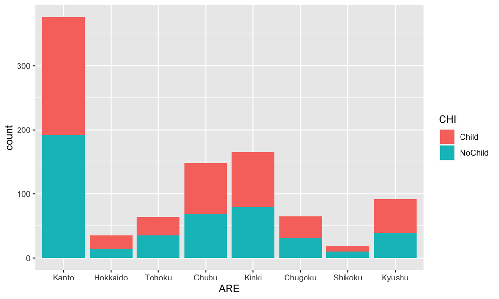

```r
library(ggplot2)
exdataset%>%
  ggplot(aes(x=ARE, fill=CHI),stat="count")+geom_bar()
```

```r
# aes()内で変数名を指定する
# が，後ほど紹介するesquisse()を使うとより容易にヒストグラムを作成できる．
```

## xtabs 関数を使う方法

```r
tablec<-xtabs(~ CHI, exdataset)
tablec
```

```
## CHI
##   Child NoChild
##     495     468
```

```r
tabled<- xtabs(~ ARE, exdataset)
tabled
```

```
## ARE
##    Kanto Hokkaido   Tohoku    Chubu    Kinki  Chugoku  Shikoku   Kyushu
##      376       35       64      148      165       65       18       92
```

## table 関数を使う方法

```r
tablee<-xtabs(~ ARE + CHI, exdataset)
tablee
```

```
##           CHI
## ARE        Child NoChild
##   Kanto      184     192
##   Hokkaido    21      14
##   Tohoku      29      35
##   Chubu       80      68
##   Kinki       86      79
##   Chugoku     34      31
##   Shikoku      8      10
##   Kyushu      53      39
```

- 行のパーセント表示

```r
tableg<-prop.table(tablee, 1)
tableg
```

```
##           CHI
## ARE            Child   NoChild
##   Kanto    0.4893617 0.5106383
##   Hokkaido 0.6000000 0.4000000
##   Tohoku   0.4531250 0.5468750
##   Chubu    0.5405405 0.4594595
##   Kinki    0.5212121 0.4787879
##   Chugoku  0.5230769 0.4769231
##   Shikoku  0.4444444 0.5555556
##   Kyushu   0.5760870 0.4239130
```

- 列のパーセント表示

```r
tableh<-prop.table(tablee, 2)
tableh
```

```
##           CHI
## ARE             Child    NoChild
##   Kanto    0.37171717 0.41025641
##   Hokkaido 0.04242424 0.02991453
##   Tohoku   0.05858586 0.07478632
##   Chubu    0.16161616 0.14529915
##   Kinki    0.17373737 0.16880342
##   Chugoku  0.06868687 0.06623932
##   Shikoku  0.01616162 0.02136752
##   Kyushu   0.10707071 0.08333333
```

## もっと細かいクロス集計表を出してみよう

```r
xtabs(~ CHI + ARE +F_SEX, exdataset)
```

```
## , , F_SEX = female
##
##          ARE
## CHI       Kanto Hokkaido Tohoku Chubu Kinki Chugoku Shikoku Kyushu
##   Child     117       11     16    49    56      24       4     33
##   NoChild   103        7     19    30    39      17       5     22
##
## , , F_SEX = male
##
##          ARE
## CHI       Kanto Hokkaido Tohoku Chubu Kinki Chugoku Shikoku Kyushu
##   Child      65       10     13    31    30      10       4     20
##   NoChild    88        7     16    37    39      14       5     16
##
## , , F_SEX = other
##
##          ARE
## CHI       Kanto Hokkaido Tohoku Chubu Kinki Chugoku Shikoku Kyushu
##   Child       2        0      0     0     0       0       0      0
##   NoChild     1        0      0     1     1       0       0      1
```

## 連関係数を出力しよう

- 連関係数：クラメール連関係数V
  - 下限が0，上限が1で完全な連関に近づくにつれて1に近い値を取る．

```r
#install.packages('vcd', dependencies = T)：初回のみ
library(vcd)
assocstats(tablee)
```

```
##                     X^2 df P(> X^2)
## Likelihood Ratio 5.1570  7  0.64082
## Pearson          5.1408  7  0.64278
##
## Phi-Coefficient   : NA
## Contingency Coeff.: 0.073
## Cramer's V        : 0.073
```

- 今回の場合は，地域と子供の有無にほとんど連関は認められませんでした．

## \(\chi\)二乗検定を行いましょう．

## \(\chi\)二乗検定

- 対立仮説：居住地域と子供の有無は独立ではない（連関がある）
- 帰無仮説：居住地域と子供の有無は独立である（連関があるとは言えない）

```r
chitest.tablee<-chisq.test(tablee)
chitest.tablee
```

```
##
##  Pearson's Chi-squared test
##
## data:  tablee
## X-squared = 5.1408, df = 7, p-value = 0.6428
```

- 検定の結果，p値が.05以上なので，対立仮説を採択できず，帰無仮説を採択する．

## \(\chi\)二乗検定

- レポートにまとめる時には，こんな書き方をします．

> \(\chi\)二乗検定を行った結果，居住地域と子供の有無は独立であることがわかった(χ=5.1408, df=7, p=.64)．
- ^2は上付きの文字だと思ってください．
- もし，\(\chi\)二乗検定でp値が.05以下であった場合，残差分析を行います．
  - どのセルで有意な逸脱が生じたのかを検討する．
  - 標準化残差が1.96以上であれば，5%水準で有意な逸脱があったと評価する．

```r
chitest.tablee$stdres
```

```
##           CHI
## ARE             Child    NoChild
##   Kanto    -1.2252616  1.2252616
##   Hokkaido  1.0367594 -1.0367594
##   Tohoku   -1.0087797  1.0087797
##   Chubu     0.7017295 -0.7017295
##   Kinki     0.2030909 -0.2030909
##   Chugoku   0.1513129 -0.1513129
##   Shikoku  -0.5961874  0.5961874
##   Kyushu    1.2524729 -1.2524729
```

## ヒートマップを作ってみよう

```
# install.packages("rpivotTable") 初回のみ
library(rpivotTable)
exdataset %>% rpivotTable()
```

- ただし，再現可能性の観点から課題が残る・・・
  - コードを出力してくれない．
  - 頑張ればできなくないけど，かなり頑張らないといけないのでつらい．
  - 参考までに使ってみると良いでしょう．

## いろいろグラフを作ってみよう

```
# install.packages("esquisse") 初回のみ
library(esquisse)
exdataset %>% esquisser()
```

- 自由にグラフを作成することができる．

## いろいろグラフを作ってみよう

```
# install.packages("DataExplorer") 初回のみ
library(DataExplorer)
exdataset %>% create_report
```

- データの記述統計量およびヒストグラムなど，基本的な記述統計を可視化してくれる．
  - ヒストグラムや欠損値など．
  - ただし，今回についてはデータがたくさんありすぎてよくわからない．

## jamoviでやってみよう

- クロス集計表の作成方法
- カイ2乗検定について

## 演習問題

## 問題

### いずれもRないしはjamoviでやってみましょう．

- 苦手な人はjamoviで，得意な人はRでやってみましょう．
- どちらでやったからといって成績上不利益を被ることはありません．
- 教科書「1.1.データの概要」および「1.1.2データの読み込み」を読んだ上で，20ページからの「1.5.2連関の分析」について，記述されている項目を各自で手を動かしてみましょう
- jamoviでは同じことを同じデータを使ってやってみましょう．